# Setup

## Installs and Imports

```python
import os

import numpy as np
import pandas as pd
import seaborn as sns
import matplotlib.pyplot as plt

from lib.visualization import format_plot
```

## Config

### I/O

```python
DATA_DIR = 'data/'
DATA_FILE = 'takehome_ds_written - takehome_ds_written.csv'
OUTFILE = 'data_cleaned.csv'
```

### Visualization

```python
# Tabular
pd.set_option('display.max_columns',500)
pd.set_option('display.max_rows',500)

# Plotting
plt.rcParams['figure.figsize'] = [15, 3]
```

# Read in Data

## File Sizes

We'll take a look at the size of our input file to make sure it can be read into memory easily. Even though we just have a single file for this exercise, the code is extensible to multiple files should we need it.

```python
files = os.listdir(DATA_DIR)
[(f, f"{round(os.path.getsize(DATA_DIR + f) / (1024 * 1024), 1)}MB") for f in files if '.csv' in f]
```

```
[('takehome_ds_written - takehome_ds_written.csv', '63.8MB')]
```

## Read

```python
data = pd.read_csv(DATA_DIR + DATA_FILE)
print(f"Dimensions: {data.shape}")
data.head()
```

```
Dimensions: (1513719, 4)
```

|  | Unnamed: 0 | merchant | time | amount_usd_in_cents |
| --- | --- | --- | --- | --- |
| 0 | 1 | faa029c6b0 | 2034-06-17 23:34:14 | 6349 |
| 1 | 2 | ed7a7d91aa | 2034-12-27 0:40:38 | 3854 |
| 2 | 3 | 5608f200cf | 2034-04-30 1:29:42 | 789 |
| 3 | 4 | 15b1a0d61e | 2034-09-16 1:06:23 | 4452 |
| 4 | 5 | 4770051790 | 2034-07-22 16:21:42 | 20203 |

# Preliminary Cleanup

We'll convert the time column to a pandas timestamp type, remove the unnamed index column, rename the amount column to be less verbose, and convert it to $ to make it easier to reason about.

We'll also remove duplicates - with a duplicate being defined as a transaction at the same timestamp by the same merchant for the same amount, corresponding to 218 rows of data.

```python
data['time'] = pd.to_datetime(data['time'])
data.drop('Unnamed: 0', axis=1, inplace=True)
data.rename(columns={'amount_usd_in_cents': 'amount'}, inplace=True)
data['amount'] = data['amount'] / 100
data.info(verbose=True)
```

```
<class 'pandas.core.frame.DataFrame'>
RangeIndex: 1513719 entries, 0 to 1513718
Data columns (total 3 columns):
 #   Column    Non-Null Count    Dtype
---  ------    --------------    -----
 0   merchant  1513719 non-null  object
 1   time      1513719 non-null  datetime64[ns]
 2   amount    1513719 non-null  float64
dtypes: datetime64[ns](1), float64(1), object(1)
memory usage: 34.6+ MB
```

```python
data.drop_duplicates(inplace=True)
data.shape
```

```
(1513501, 3)
```

# Preprocessing

Let's add a time diff column to better understand the frequency of transactions per merchant

```python
data['time'] = pd.to_datetime(data['time'])
data.sort_values(by=['merchant', 'time'], inplace=True)
data['time_diff_days'] = round(data.groupby('merchant')['time'].diff().dt.total_seconds() / (3600 * 24), 2)
```

# Exploration

## Overview

```python
data.info(verbose=True)
```

```
<class 'pandas.core.frame.DataFrame'>
Index: 1513501 entries, 438308 to 606486
Data columns (total 4 columns):
 #   Column          Non-Null Count    Dtype
---  ------          --------------    -----
 0   merchant        1513501 non-null  object
 1   time            1513501 non-null  datetime64[ns]
 2   amount          1513501 non-null  float64
 3   time_diff_days  1499150 non-null  float64
dtypes: datetime64[ns](1), float64(2), object(1)
memory usage: 57.7+ MB
```

```python
print("There don't appear to be any null values")
print(f"Number of merchants: {data['merchant'].nunique()}")
print(f"Dataset Start: {data['time'].min()}")
print(f"Dataset End: {data['time'].max()}")
print(f"Total Tx Volume: ${round(data['amount'].sum(), 2)}")
print(f"Average Tx Amount: ${round(data['amount'].mean(), 2)}")
print(f"Median Tx Amount: ${round(data['amount'].median(), 2)}")
print(f"Average Time Between Transactions: {round(data['time_diff_days'].mean(), 2)} days")
print(f"Median Time Between Transactions: {round(data['time_diff_days'].median() * 24, 2)} hours")
```

```
There don't appear to be any null values
Number of merchants: 14351
Dataset Start: 2033-01-01 09:38:32
Dataset End: 2034-12-31 07:59:40
Total Tx Volume: $234335358.45
Average Tx Amount: $154.83
Median Tx Amount: $61.03
Average Time Between Transactions: 1.91 days
Median Time Between Transactions: 1.68 hours
```

## Trends

There is a steady upward trend in total transaction volume, the number of merchants, and the number of transactions. The average transaction amount is relatively stable following some initial volatility. There doesn't appear to be strong seasonality in the data in aggregate - though this might be apparent at the merchant level.

```python
data.set_index(pd.DatetimeIndex(data['time']), drop=True, inplace=True)
```

```python
monthly_resample = data.groupby(pd.Grouper(freq='M'))
month_labels = pd.date_range(start=data.index.min(), end=data.index.max(), freq='MS').strftime('%Y-%m').tolist()
```

### Total Transaction Volume

The volume seems to be rising steadily for the most part with some minor dips

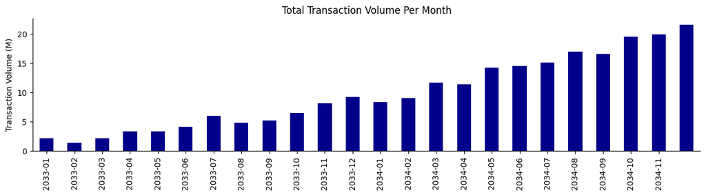

```python
(monthly_resample['amount'].sum() / 1000000).plot.bar(color='darkblue')
plt.xticks(range(len(month_labels)), month_labels, rotation='vertical')
format_plot("Total Transaction Volume Per Month", "", "Transaction Volume (M)")
```

### Number of Merchants

The number of merchants using our platform is steadily climbing at a fairly even pace

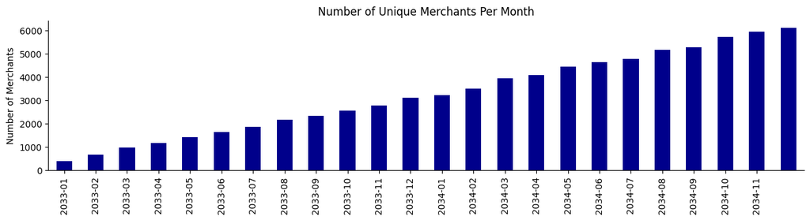

```python
monthly_resample['merchant'].nunique().plot.bar(color='darkblue')
plt.xticks(range(len(month_labels)), month_labels, rotation='vertical')
format_plot("Number of Unique Merchants Per Month", "", "Number of Merchants")
```

### Number of Transactions

Transaction count follows a pattern similar to the total transaction volume, rising steadily for the most part

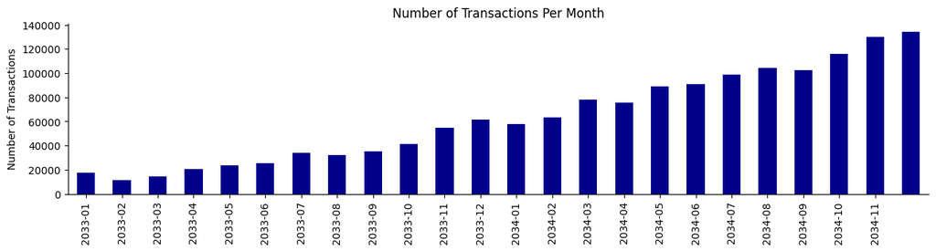

```python
monthly_resample['time'].size().plot.bar(color='darkblue')
plt.xticks(range(len(month_labels)), month_labels, rotation='vertical')
format_plot("Number of Transactions Per Month", "", "Number of Transactions")
```

### Average Transaction Amount

After some volatility early in 2033, average transaction amounts are failry stable over time

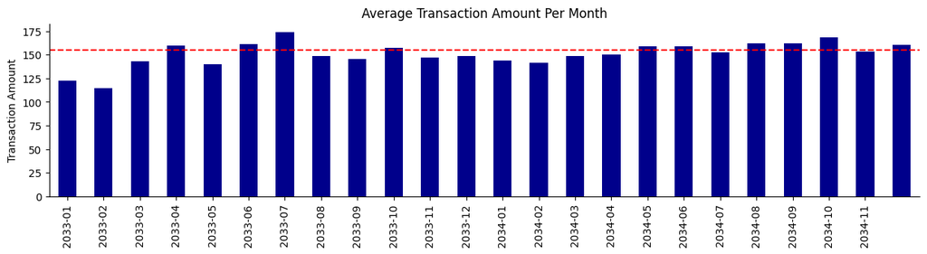

```python
(monthly_resample['amount'].mean()).plot.bar(color='darkblue')
plt.xticks(range(len(month_labels)), month_labels, rotation='vertical')
plt.axhline(data['amount'].mean(), color='red', linestyle='dashed', label='TxAverage')
format_plot("Average Transaction Amount Per Month", "", "Transaction Amount")
```

### Median Transaction Frequency

The transaction frequency seems to be somewhat volatile

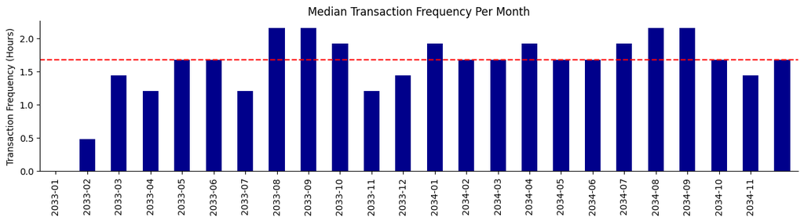

```python
(monthly_resample['time_diff_days'].median() * 24).plot.bar(color='darkblue')
plt.xticks(range(len(month_labels)), month_labels, rotation='vertical')
plt.axhline(data['time_diff_days'].median() * 24, color='red', linestyle='dashed', label='TxFreqMedian')
format_plot("Median Transaction Frequency Per Month", "", "Transaction Frequency (Hours)")
```

## Distributions

```python
group_merchant = data.groupby('merchant')
```

### Total Transaction Volume

The distrubution is extremely skewed, with some merhchants transacting more than USD2M over our time frame. The majority however, are in the $100-10,000 range - this is more easily observed on a log scale

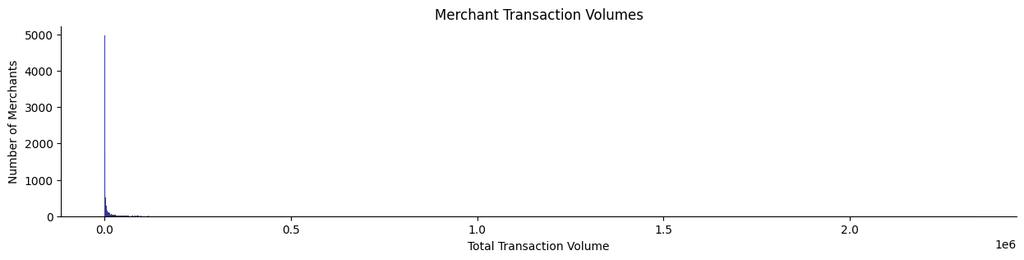

```python
sns.histplot(group_merchant['amount'].sum(), color='darkblue')
format_plot("Merchant Transaction Volumes", "Total Transaction Volume", "Number of Merchants")
```

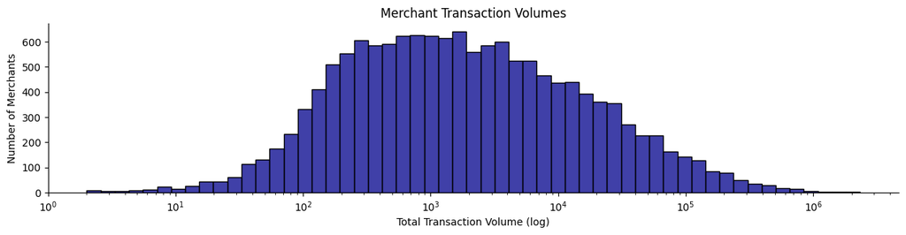

```python
sns.histplot(group_merchant['amount'].sum(), log_scale=True, color='darkblue')
format_plot("Merchant Transaction Volumes", "Total Transaction Volume (log)", "Number of Merchants")
```

Taking a look at merchants with over $1M in transaction volume, they appear to be legitimate accounts with high transaction frequencies and counts

```python
high_vol_merchants = group_merchant['amount'].sum().loc[lambda x: x > 1000000].index.tolist()

merchant_metrics = data[data['merchant'].isin(high_vol_merchants)].groupby('merchant').agg({
    'amount': ['sum', 'count', 'mean', 'median', 'std', 'min', 'max'],
    'time_diff_days': ['mean', 'median', 'std', 'min', 'max']
}).reset_index()

merchant_metrics.columns = ['merchant',
                            'total_tx_volume',
                            'tx_count',
                            'avg_tx_amount',
                            'median_tx_amount',
                            'std_tx_amount',
                            'min_tx_amount',
                            'max_tx_amount',
                            'avg_tx_freq',
                            'median_tx_freq',
                            'std_tx_freq',
                            'min_tx_freq',
                            'max_tx_freq']

print(merchant_metrics.shape)
merchant_metrics
```

```
(7, 13)
```

|  | merchant | total_tx_volume | tx_count | avg_tx_amount | median_tx_amount | std_tx_amount | min_tx_amount | max_tx_amount | avg_tx_freq | median_tx_freq | std_tx_freq | min_tx_freq | max_tx_freq |
| --- | --- | --- | --- | --- | --- | --- | --- | --- | --- | --- | --- | --- | --- |
| 0 | 366ba8e0da | 1019238.87 | 363 | 2807.820579 | 1801.15 | 3343.333834 | 121.31 | 32877.83 | 1.234171 | 0.80 | 1.489195 | 0.0 | 13.33 |
| 1 | 44ee3ec72c | 2330451.39 | 4894 | 476.185409 | 478.41 | 155.972213 | 2.84 | 2630.11 | 0.011931 | 0.00 | 0.529515 | 0.0 | 30.44 |
| 2 | 654930c922 | 1509318.06 | 11191 | 134.868918 | 92.76 | 309.277213 | 11.78 | 22062.68 | 0.064060 | 0.00 | 3.824053 | 0.0 | 392.08 |
| 3 | 78639fbae7 | 1089211.62 | 10527 | 103.468378 | 90.78 | 73.239544 | 2.09 | 1218.13 | 0.063255 | 0.03 | 0.098147 | 0.0 | 1.04 |
| 4 | 82897075ed | 1103020.95 | 4199 | 262.686580 | 251.22 | 101.832309 | 2.56 | 1171.37 | 0.102203 | 0.00 | 1.148808 | 0.0 | 32.65 |
| 5 | bdebc6831e | 2187712.80 | 6179 | 354.056126 | 353.96 | 195.840146 | 2.03 | 4379.12 | 0.108114 | 0.02 | 0.947637 | 0.0 | 58.56 |
| 6 | ce61387781 | 1420024.23 | 3367 | 421.747618 | 391.17 | 199.878505 | 2.36 | 3536.82 | 0.144195 | 0.00 | 1.553418 | 0.0 | 41.06 |

### Number of Transactions

Interestingly, a large number of merchants have fewer than 10 transactions, with the majority having fewer than 100

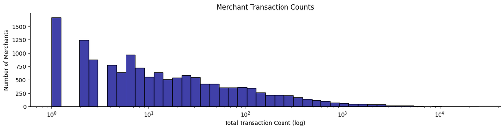

```python
sns.histplot(group_merchant['amount'].count(), log_scale=True, color='darkblue')
format_plot("Merchant Transaction Counts", "Total Transaction Count (log)", "Number of Merchants")
```

### Transaction Amounts

There's a wide skew in average transaction amounts by merchant, as well as a great deal of variability in transaction amount within merchants.

```python
group_merchant['amount'].mean().sort_values()
```

```
merchant
83c1813b63        2.010000
dcc0c1c755        2.060000
fe9bf14103        2.090000
9963a11d63        2.173333
7347d3b20c        2.180000
                  ...
4e5d7ec3de    21648.757500
26f51e4c7e    27630.062500
42229128c1    40475.210000
0838e4078e    87819.843333
b993083163    88874.651667
Name: amount, Length: 14351, dtype: float64
```

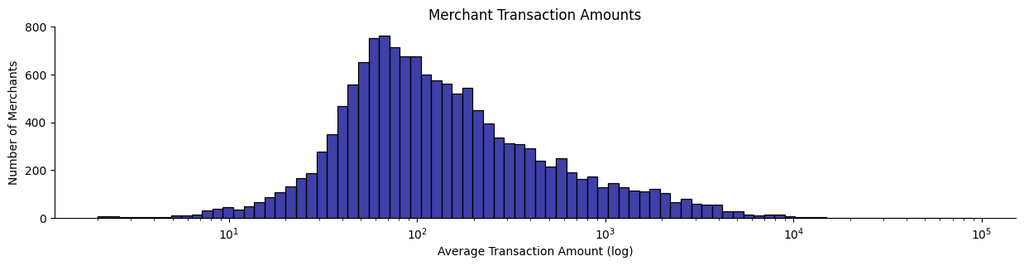

```python
sns.histplot(group_merchant['amount'].mean(), log_scale=True, color='darkblue')
format_plot("Merchant Transaction Amounts", "Average Transaction Amount (log)", "Number of Merchants")
```

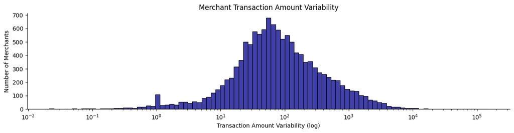

```python
tx_amt_variability = group_merchant['amount'].std().reset_index()
tx_amt_variability['amount'] = np.where(tx_amt_variability['amount'] == 0, 1, tx_amt_variability['amount'])
sns.histplot(tx_amt_variability['amount'], log_scale=True, color='darkblue')
format_plot("Merchant Transaction Amount Variability", "Transaction Amount Variability (log)", "Number of Merchants")
```

### Volatility

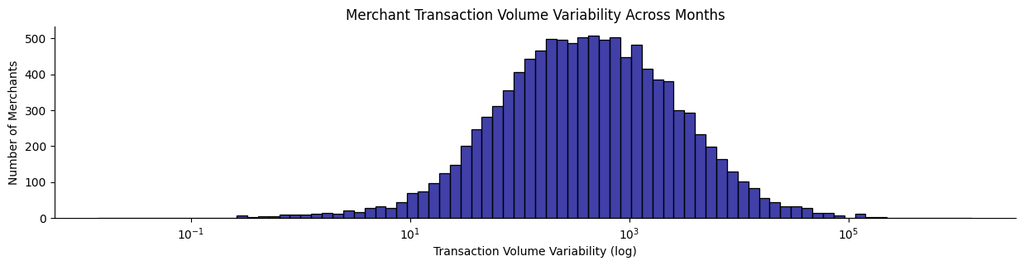

```python
monthly_vol_by_merchant = data.groupby(['merchant', data['time'].dt.month])['amount'].sum().reset_index()
monthly_dev = monthly_vol_by_merchant.groupby('merchant')['amount'].std().dropna()
sns.histplot(monthly_dev[monthly_dev > 0], log_scale=True, color='darkblue')
format_plot("Merchant Transaction Volume Variability Across Months", "Transaction Volume Variability (log)", "Number of Merchants")
```

### Transaction Frequency

```python
merch_freq = data.groupby('merchant')['time_diff_days']
```

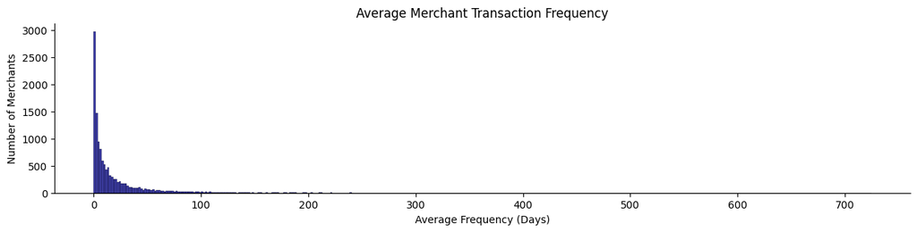

```python
sns.histplot(merch_freq.mean(), color='darkblue')
format_plot("Average Merchant Transaction Frequency", "Average Frequency (Days)", "Number of Merchants")
```

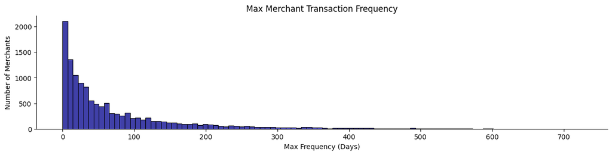

```python
sns.histplot(merch_freq.max(), color='darkblue')
format_plot("Max Merchant Transaction Frequency", "Max Frequency (Days)", "Number of Merchants")
```

### Recency

#### Time Since Last Transaction

While most merchants have transactions close to the end of the dataset, for many it's been 3, 6, 9 months or longer since their last transaction. This is evident in the proportion of total transaction volume in the most recent quarter as well.

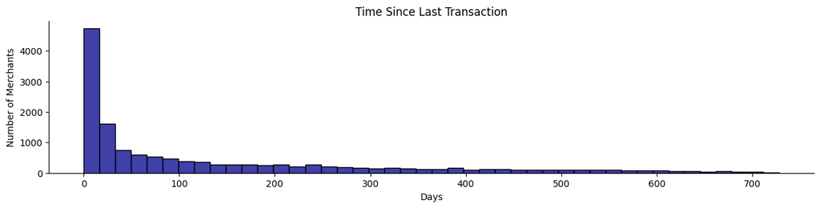

```python
time_since_last_tx = data.index.max() - group_merchant['time'].max()
time_since_last_tx_days = round(time_since_last_tx.dt.total_seconds() / (3600 * 24), 1)
sns.histplot(time_since_last_tx_days, color='darkblue')
format_plot("Time Since Last Transaction", "Days", "Number of Merchants")
```

#### Proportion of Total Volume in the Most Recent Quarter

Merchants appear to follow a bimodal distribution when it comes to proportion of total spend in the most recent quarter, indicating a fair bit of churn, some steady business, and new merchants starting on the platform this quarter

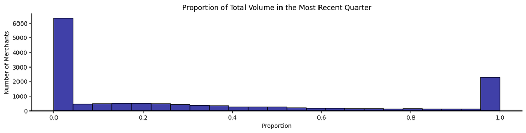

```python
data['quarter'] = data['time'].dt.to_period("Q")
Q434_vol = data[data['quarter'] == "2034Q4"].groupby('merchant')['amount'].sum()
total_vol = data.groupby('merchant')['amount'].sum()
recent_prop = Q434_vol / total_vol
recent_prop.fillna(0, inplace=True)
sns.histplot(recent_prop, color='darkblue')
format_plot("Proportion of Total Volume in the Most Recent Quarter", "Proportion", "Number of Merchants")
```

### Business Trend

We similarly see a bimodal distribution in the proportion of peak volume handled this quarter per merchant

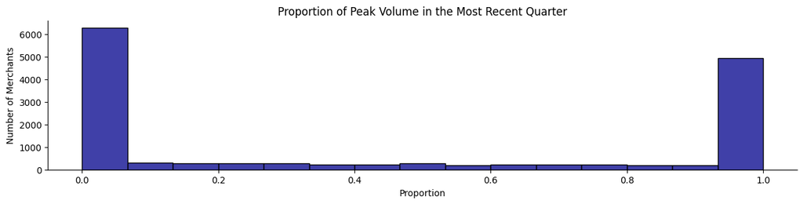

```python
max_vol = data.groupby(['merchant', 'quarter'])['amount'].agg('sum').groupby('merchant').max()
max_prop =  Q434_vol / max_vol
max_prop.fillna(0, inplace=True)
sns.histplot(max_prop, color='darkblue')
format_plot("Proportion of Peak Volume in the Most Recent Quarter", "Proportion", "Number of Merchants")
```

## Seasonality

Based on the aggregated transaction volume by month, there doesn't seem to be a strong seasonal effect at the month, quarter level, which is period of interest for this exercise. Seasonal effects may exist at the weekly or merchant level, and if they do, they will be captured with merchant level features for modeling

## Takeaways

The total transaction volume, number of merchants, number of transactions on the platform are steadily growing. While the average transaction amount is steady following an early bout of volatility, the median transaction frequency moves around a fair bit over time. Certain algorithms (e.g., decision trees) don't generalize well on long term trends, though the extent to which this is an issue will depend on if the trends are observed within merchants as well, and can be addressed via feature engineering (assigning relative ranks and using comparisons to their own past characteristics). We'll explore this some more when we're doing feature engineering.

There don't seem to be strong seasonal effects at the aggregate level, though these may be evident for some merchants.

As expected, across merchants the total transaction volume, number of transactions, volatility, and to a lesser extent the transaction frequency follow a power law distribution.

Unexpectedly, a significant proportion of merchants go many months between transactions - we'll have to be deliberate with our churn assignments.

Lastly, while there are outliers, they appear to be organic accounts.

# Write cleaned data

```python
data.drop('quarter', axis=1, inplace=True)
```

```python
# data.to_csv(DATA_DIR + OUTFILE, index=False)
```